# FOSS For Spectroscopy

Bryan A. Hanson, DePauw University

2021-04-15 04:05 UTC

The following table collects information about free and open source software ([FOSS](https://en.wikipedia.org/wiki/Free_and_open-source_software)) for spectroscopy. All information is taken from the respective websites and/or repositories. Some projects have been described in publications. If so, a link is provided, but the document may be behind a paywall.

Unless otherwise noted, the software mentioned here:

- Is suitable for one or more of the following techniques: NMR, IR, Raman, ESR/EPR, fluorescence, XRF, LIBS and UV-Vis.
- Mass *spectrometry* software is not included (see the work by Stanstrup just below).
- Software for MRI is not included.

[Stanstrup *et al.*](https://www.mdpi.com/2218-1989/9/10/200) have published a comprehensive paper describing the `R` packages suitable for use in metabolomics, which partially overlaps with the information here. The authors have also created a dynamic [document](https://rformassspectrometry.github.io/metaRbolomics-book/) with the same information and more. In addition, awesome-spectra is a page somewhat in the spirit of the work here, but apparently depends on authors to add their own material, and is missing some key entries (e.g. no NMR packages).

The [CRAN Task View for Chemometrics & Computational Physics](https://cran.r-project.org/web/views/ChemPhys.html) includes some `R` packages listed here as well as related software.

#### How Does One Choose a Package?

*The projects listed here have been lightly vetted. If a project looks incomplete, or I can’t tell what it does, it’s not included!* With that in mind, there are still many packages to consider. As a general guide, the excellent checklist provided by [Lortie *et al.*](https://onlinelibrary.wiley.com/doi/full/10.1002/ece3.5970) is included here for your consideration.

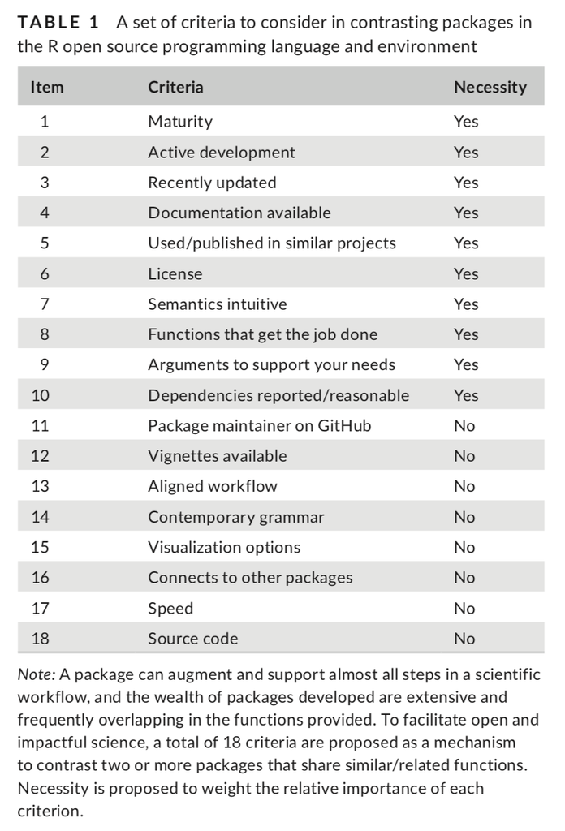

- *Click on a header to sort the table (“Focus” may be a good starting point)*
- Abbreviations & terms below the table
- The table currently has 117 entries; the majority are `R` (43) or `Python` (57).

| Name | Description | Lang | Focus | Status |
| --- | --- | --- | --- | --- |
| albatross | PARAFAC of EEM | R | EEM | 2021-04-02 |
| [ANATOLIA](http://anatolia.nmrclub.ru/) ([pub](https://onlinelibrary.wiley.com/doi/abs/10.1002/mrc.4689)) | NMR lineshape analysis | C++ | NMR (Bruker) | 2019-10-22 |
| apogee ([pub](https://arxiv.org/abs/1510.06745)) | Tools for working with APOGEE data | Python | IR | 2020-12-28 |
| BaMORC ([pub](https://link.springer.com/article/10.1007%2Fs10858-018-0202-5)) | Automated 13C assignments in proteins | R | NMR (13C) | 2019-01-01 |
| baseline | Baseline correction | R | Any | 2020-09-11 |
| [BATMAN](http://batman.r-forge.r-project.org/) ([pub](https://arxiv.org/abs/1105.2204)) | Estimation of metabolite concentrations from 1H NMR | R | NMR (1D) |  |
| [bfit](https://pypi.org/project/bfit/) | Visualize NMR data | Python | NMR (1D) | 2021-04-05 |
| [BICePs](https://pypi.org/project/biceps/) ([pub](https://pubs.acs.org/doi/10.1021/acs.jpcb.7b11871)) | Bayesian inference of conformational populations from NMR data | Python | NMR | 2021-02-15 |
| [bionmr-utils](https://pypi.org/project/bionmr-utils/) | Biological NMR utilities | Python | NMR | 2019-11-07 |
| [blochsimu](https://pypi.org/project/blochsimu/) | Simulation of Bloch equations | Python | NMR | 2015-04-26 |
| BMRBr | Interface to BMRB database | R | Data sharing | 2019-03-07 |
| brukeropusreader | Read Bruker OPUS files | Python | Data Sharing (IR) | 2021-03-07 |
| [CARA](http://cara.nmr.ch/doku.php) | Biomolecular NMR peak assignment | C++, Qt | NMR | 2020-09-17 |
| [ChemEx](https://pypi.org/project/chemex/) | Analysis of chemical exchange by NMR | Python | NMR | 2021-04-09 |
| [ChemoSpec](https://bryanhanson.github.io/ChemoSpec/) | EDA of 1D spectra | R | Any | 2021-03-31 |
| [ChemoSpec2D](https://bryanhanson.github.io/ChemoSpec2D/) | EDA of 2D NMR | R | NMR (2D) | 2021-03-16 |
| [CheShift](https://github.com/BIOS-IMASL/cheshift) ([pub](https://www.pnas.org/content/110/42/16826)) | Prediction 13C shifts in proteins | Python | NMR (13C) | 2017-06-13 |
| ChiantiPy | Calculate radiative properties of astrophysical plasmas | Python | UV-Vis-IR | 2021-04-13 |
| COMPASS ([pub](https://journals.plos.org/ploscompbiol/article?id=10.1371/journal.pcbi.1004022)) | Protein backbone assignments from triple-resonance peak lists | Qt | NMR | 2020-09-13 |
| corr2D ([pub](https://www.jstatsoft.org/article/view/v090i03)) | 2D correlation spectroscopy | R | IR | 2021-01-07 |
| CRIkit2 ([pub](https://www.ncbi.nlm.nih.gov/pubmed/28819335)) | Hyperspectral imaging toolkit | Python | Raman | 2020-10-28 |
| [crispy](http://www.esrf.eu/computing/scientific/crispy/) | Calculate & plot core-level spectra | Python | XAS | 2021-04-06 |
| curvit | Create light curves from UV imaging telescope data | Python | UV | 2021-02-07 |
| DeepSpectroscopy | Spectroscopy with deep learning | Python | Any | 2018-05-19 |
| [drawnmr](https://pypi.org/project/drawnmr/) | Visualize NMR data | Python | NMR | 2017-12-01 |
| EEM | Analysis of EEM data | R | EEM | 2018-06-02 |
| eemR | Preprocessing EEM data | R | EEM | 2020-11-19 |
| [es](https://c3.lbl.gov/es/) | Elementary supernova spectrum synthesis | Python | UV-Vis | 2019-03-24 |
| [FAM-N](https://pypi.org/project/famn-opt/) ([pub](https://pubs.acs.org/doi/10.1021/jp505752c)) | Optimize composite pulses for MQMAS | Python | NMR (SS) | 2019-07-14 |
| [Farseer-NMR](https://farseer-nmr.github.io/FarSeer-NMR/) ([pub](https://link.springer.com/article/10.1007/s10858-018-0182-5)) | Analysis & plotting of biological NMR peak lists | Python | NMR (2D) | 2020-01-30 |

[output cut: 87 more lines]

Additions or corrections? Please [file an issue](https://github.com/bryanhanson/FOSS4Spectroscopy/issues) with the necessary information or submit a pull request at the [repo](https://github.com/bryanhanson/FOSS4Spectroscopy).

##### Status Column:

The status column in the table gives the date of the most recent:

- commit to a repository,
- activity on an issue filed in a repository,
- web site update, or
- submission to an archival network such as CRAN or PyPI

as a proxy for regular maintenance. Keep in mind that some software is fairly mature and thus an older status date does not necessarily mean the software is not maintained. Follow the links to the websites for more details.

*The status date is found by automatic checking of sites with valid links. Commits and issues are only checked for Github sites, via the Github API. Web site updates are found using a simple search for common date formats and may be inaccurate. Keep in mind the most recent activity may be on any branch in a repo, and may be newer than any official releases.*

##### Abbreviations & Terms:

- **CRAN:** [Comprehensive R Archival Network](https://cran.r-project.org/)
- **EDA:** Exploratory data analysis (unsupervised chemometrics)
- **Focus:** The type of spectroscopy the software is focused on. Keep in mind that software designed with a given spectroscopy in mind may still work with other types of spectroscopic data.
- **Language:** Most software is built on several languages. In the table, “lang” refers to the primary language used to create the software.
- **PyPI:** [Python Package Index](https://pypi.org/)
- **Python:** Multipurpose programming language [details](https://www.python.org/about/)
- **R:** A software environment for statistical computing and graphics [details, platforms](https://www.r-project.org/)